# Produit Scalaire

Anicet TAXIL

# Incontournables

### Exercice préléminaire:

Lire graphiquement les coordonnées des vecteurs $\vec{u}$, $\vec{v}$ et $\vec{w}$ dans le repère ci-dessous.

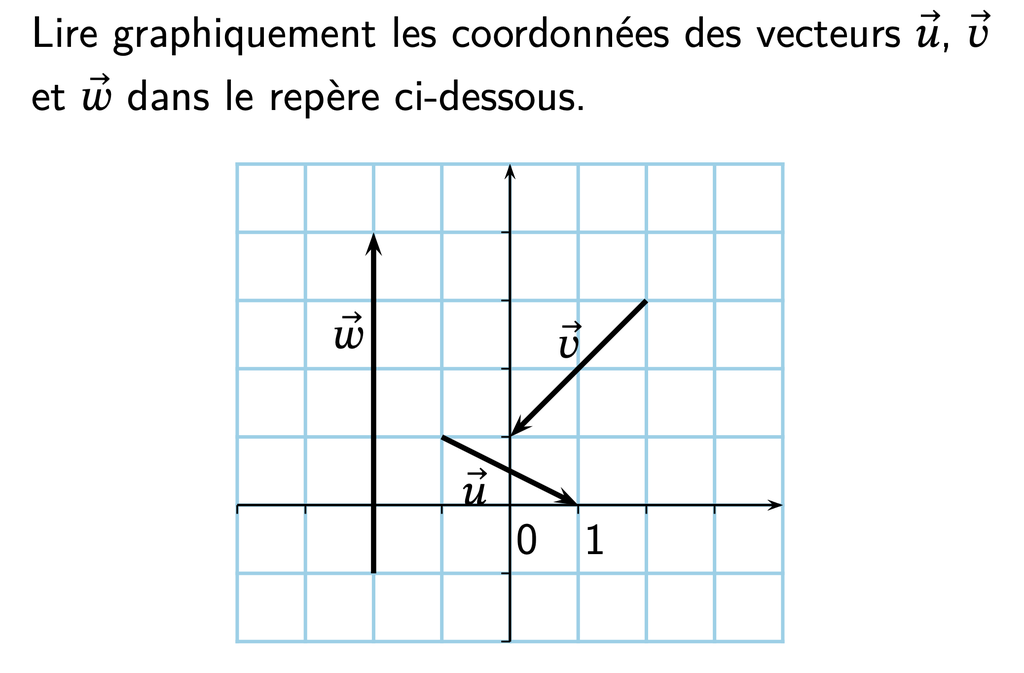

### Exercice : Colinéarité des vecteurs

Les vecteurs suivants sont-ils colinéaires ?

1. $\vec{u} \begin{pmatrix} 3 \\ -1 \end{pmatrix}$ et $\vec{v} \begin{pmatrix} -6 \\ 2 \end{pmatrix}$
2. $\vec{u} \begin{pmatrix} 0 \\ 4 \end{pmatrix}$ et $\vec{v} \begin{pmatrix} 0 \\ -1 \end{pmatrix}$
3. $\vec{u} \begin{pmatrix} -14 \\ 28 \end{pmatrix}$ et $\vec{v} \begin{pmatrix} -8 \\ 12 \end{pmatrix}$

### Exercice : Relation de Chasles

À l’aide de la relation de Chasles, simplifier les expressions suivantes :

1. $\overrightarrow{AB} - \overrightarrow{AC} + \overrightarrow{BC}$
2. $\overrightarrow{AB} + 2\overrightarrow{BD} - \overrightarrow{CA} + \overrightarrow{CB}$

### Exercice : Alignement de vecteurs

Dans chacun des cas suivants, déterminer si les points $A$, $B$ et $C$ sont alignés.

1. $A(-9 \ ; \ 4)$, $B(1 \ ; \ -1)$ et $C(4 \ ; \ -2)$
2. $A(-4 \ ; \ 0)$, $B(-2 \ ; \ 1)$ et $C\left(3 \ ; \ \frac{7}{2}\right)$
3. $A(-4 \ ; \ 4)$, $B(-4 \ ; \ 6)$ et $C(-3 \ ; \ 2)$

### Exercice : Produit Scalaire classique

$Soit \ ABC\ un\ triangle\ tel\ que\ AB = 5,\ AC=3\ et\ \widehat{BAC}= \frac{3\pi}{4};$

$Determiner\ \overrightarrow{AB}\ \cdot \ \overrightarrow{AC}$

# Travail de Fond

$Considérons\ la\ figure\ suivante,\ représentant\ un\ losange\ ABCD\ dans\ un\ repère\ orthonormal\ (O, \vec{i}, \vec{j})$

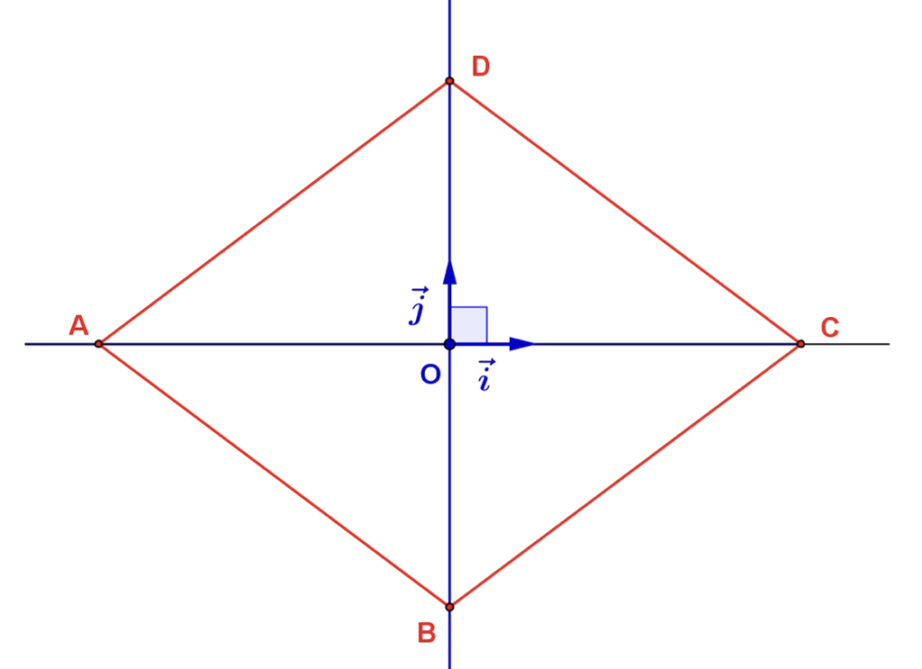

$$Après\ avoir\ donné\ la\ norme\ de\
\overrightarrow{CD},\ calculer\ \overrightarrow{OA} \cdot
\overrightarrow{OC} \ ;\ \overrightarrow{OB} \cdot \overrightarrow{OA} \
;\ \overrightarrow{BC} \cdot \overrightarrow{AD} \ ;\
\overrightarrow{BC} \cdot \overrightarrow{BA} \ sachant\ que\ OA=OC=4\
et\ OB=OD=3$$

# Pour aller plus loin

$ABC$ est un triangle tel que $AB = 5$.  
Déterminer l’ensemble des points $M$ du plan tels que :

1. $\vec{AB} \cdot (\vec{MA} + \vec{MB}) = 0$
2. $\vec{AB} \cdot \vec{AM} = 2$
3. $MA^2 + MB^2 = AB^2$
4. $(\vec{MA} + \vec{MB} - 2\vec{MC}) \cdot (\vec{MA} + \vec{MB} + \vec{MC}) = 0$